# Optimal Treatment Analysis

## Outcome Variable

**Outcome Variable:** whz

## Predictor Variables

**Intervention Variable:** predfeed3

**Adjustment Set:**

- arm
- sex
- month
- brthmon
- W_mage
- meducyrs
- feducyrs
- hhwealth_quart
- hfoodsec
- W_mhtcm
- vagbrth
- W_gagebrth
- W_birthwt
- W_birthlen
- W_nrooms
- W_nchldlt5
- W_parity
- impfloor
- impsan
- safeh20
- delta_W_mage
- delta_meducyrs
- delta_feducyrs
- delta_hhwealth_quart
- delta_hfoodsec
- delta_W_mhtcm
- delta_vagbrth
- delta_W_gagebrth
- delta_W_birthwt
- delta_W_birthlen
- delta_W_nrooms
- delta_W_nchldlt5
- delta_W_parity
- delta_impfloor
- delta_impsan
- delta_safeh20

## Stratifying Variables

The analysis was stratified on these variable(s):

- agecat
- studyid
- country

## Data Summary

| agecat | studyid | country | predfeed3 | n_cell | n |
| --- | --- | --- | --- | --- | --- |
| Birth | ki0047075b-MAL-ED | BANGLADESH | 1 | 193 | 227 |
| Birth | ki0047075b-MAL-ED | BANGLADESH | 0 | 34 | 227 |
| Birth | ki0047075b-MAL-ED | BRAZIL | 1 | 97 | 177 |
| Birth | ki0047075b-MAL-ED | BRAZIL | 0 | 80 | 177 |
| Birth | ki0047075b-MAL-ED | INDIA | 1 | 150 | 193 |
| Birth | ki0047075b-MAL-ED | INDIA | 0 | 43 | 193 |
| Birth | ki0047075b-MAL-ED | NEPAL | 1 | 97 | 166 |
| Birth | ki0047075b-MAL-ED | NEPAL | 0 | 69 | 166 |
| Birth | ki0047075b-MAL-ED | PERU | 1 | 177 | 265 |
| Birth | ki0047075b-MAL-ED | PERU | 0 | 88 | 265 |
| Birth | ki0047075b-MAL-ED | SOUTH AFRICA | 1 | 87 | 231 |
| Birth | ki0047075b-MAL-ED | SOUTH AFRICA | 0 | 144 | 231 |
| Birth | ki0047075b-MAL-ED | TANZANIA, UNITED REPUBLIC OF | 1 | 49 | 114 |
| Birth | ki0047075b-MAL-ED | TANZANIA, UNITED REPUBLIC OF | 0 | 65 | 114 |
| Birth | ki1000109-EE | PAKISTAN | 1 | 1 | 1 |
| Birth | ki1000109-EE | PAKISTAN | 0 | 0 | 1 |
| Birth | kiGH5241-JiVitA-3 | BANGLADESH | 1 | 6710 | 7406 |
| Birth | kiGH5241-JiVitA-3 | BANGLADESH | 0 | 696 | 7406 |
| Birth | kiGH5241-JiVitA-4 | BANGLADESH | 1 | 9 | 9 |
| Birth | kiGH5241-JiVitA-4 | BANGLADESH | 0 | 0 | 9 |
| 6 months | ki0047075b-MAL-ED | BANGLADESH | 1 | 203 | 237 |
| 6 months | ki0047075b-MAL-ED | BANGLADESH | 0 | 34 | 237 |
| 6 months | ki0047075b-MAL-ED | BRAZIL | 1 | 116 | 209 |
| 6 months | ki0047075b-MAL-ED | BRAZIL | 0 | 93 | 209 |
| 6 months | ki0047075b-MAL-ED | INDIA | 1 | 178 | 233 |
| 6 months | ki0047075b-MAL-ED | INDIA | 0 | 55 | 233 |
| 6 months | ki0047075b-MAL-ED | NEPAL | 1 | 132 | 233 |
| 6 months | ki0047075b-MAL-ED | NEPAL | 0 | 101 | 233 |
| 6 months | ki0047075b-MAL-ED | PERU | 1 | 183 | 270 |
| 6 months | ki0047075b-MAL-ED | PERU | 0 | 87 | 270 |
| 6 months | ki0047075b-MAL-ED | SOUTH AFRICA | 1 | 86 | 248 |
| 6 months | ki0047075b-MAL-ED | SOUTH AFRICA | 0 | 162 | 248 |
| 6 months | ki0047075b-MAL-ED | TANZANIA, UNITED REPUBLIC OF | 1 | 91 | 240 |
| 6 months | ki0047075b-MAL-ED | TANZANIA, UNITED REPUBLIC OF | 0 | 149 | 240 |
| 6 months | ki1000109-EE | PAKISTAN | 1 | 349 | 375 |
| 6 months | ki1000109-EE | PAKISTAN | 0 | 26 | 375 |
| 6 months | ki1113344-GMS-Nepal | NEPAL | 1 | 379 | 458 |
| 6 months | ki1113344-GMS-Nepal | NEPAL | 0 | 79 | 458 |
| 6 months | kiGH5241-JiVitA-3 | BANGLADESH | 1 | 7350 | 8075 |
| 6 months | kiGH5241-JiVitA-3 | BANGLADESH | 0 | 725 | 8075 |
| 6 months | kiGH5241-JiVitA-4 | BANGLADESH | 1 | 20 | 22 |
| 6 months | kiGH5241-JiVitA-4 | BANGLADESH | 0 | 2 | 22 |
| 24 months | ki0047075b-MAL-ED | BANGLADESH | 1 | 178 | 208 |
| 24 months | ki0047075b-MAL-ED | BANGLADESH | 0 | 30 | 208 |
| 24 months | ki0047075b-MAL-ED | BRAZIL | 1 | 98 | 169 |
| 24 months | ki0047075b-MAL-ED | BRAZIL | 0 | 71 | 169 |
| 24 months | ki0047075b-MAL-ED | INDIA | 1 | 170 | 225 |
| 24 months | ki0047075b-MAL-ED | INDIA | 0 | 55 | 225 |
| 24 months | ki0047075b-MAL-ED | NEPAL | 1 | 128 | 225 |
| 24 months | ki0047075b-MAL-ED | NEPAL | 0 | 97 | 225 |
| 24 months | ki0047075b-MAL-ED | PERU | 1 | 137 | 199 |
| 24 months | ki0047075b-MAL-ED | PERU | 0 | 62 | 199 |
| 24 months | ki0047075b-MAL-ED | SOUTH AFRICA | 1 | 81 | 232 |
| 24 months | ki0047075b-MAL-ED | SOUTH AFRICA | 0 | 151 | 232 |
| 24 months | ki0047075b-MAL-ED | TANZANIA, UNITED REPUBLIC OF | 1 | 79 | 210 |
| 24 months | ki0047075b-MAL-ED | TANZANIA, UNITED REPUBLIC OF | 0 | 131 | 210 |
| 24 months | ki1113344-GMS-Nepal | NEPAL | 1 | 336 | 404 |
| 24 months | ki1113344-GMS-Nepal | NEPAL | 0 | 68 | 404 |
| 24 months | kiGH5241-JiVitA-3 | BANGLADESH | 1 | 3734 | 4145 |
| 24 months | kiGH5241-JiVitA-3 | BANGLADESH | 0 | 411 | 4145 |
| 24 months | kiGH5241-JiVitA-4 | BANGLADESH | 1 | 36 | 38 |
| 24 months | kiGH5241-JiVitA-4 | BANGLADESH | 0 | 2 | 38 |

The following strata were considered:

- agecat: 24 months, studyid: ki0047075b-MAL-ED, country: BANGLADESH
- agecat: 24 months, studyid: ki0047075b-MAL-ED, country: BRAZIL
- agecat: 24 months, studyid: ki0047075b-MAL-ED, country: INDIA
- agecat: 24 months, studyid: ki0047075b-MAL-ED, country: NEPAL
- agecat: 24 months, studyid: ki0047075b-MAL-ED, country: PERU
- agecat: 24 months, studyid: ki0047075b-MAL-ED, country: SOUTH AFRICA
- agecat: 24 months, studyid: ki0047075b-MAL-ED, country: TANZANIA, UNITED REPUBLIC OF
- agecat: 24 months, studyid: ki1113344-GMS-Nepal, country: NEPAL
- agecat: 24 months, studyid: kiGH5241-JiVitA-3, country: BANGLADESH
- agecat: 24 months, studyid: kiGH5241-JiVitA-4, country: BANGLADESH
- agecat: 6 months, studyid: ki0047075b-MAL-ED, country: BANGLADESH
- agecat: 6 months, studyid: ki0047075b-MAL-ED, country: BRAZIL
- agecat: 6 months, studyid: ki0047075b-MAL-ED, country: INDIA
- agecat: 6 months, studyid: ki0047075b-MAL-ED, country: NEPAL
- agecat: 6 months, studyid: ki0047075b-MAL-ED, country: PERU
- agecat: 6 months, studyid: ki0047075b-MAL-ED, country: SOUTH AFRICA
- agecat: 6 months, studyid: ki0047075b-MAL-ED, country: TANZANIA, UNITED REPUBLIC OF
- agecat: 6 months, studyid: ki1000109-EE, country: PAKISTAN
- agecat: 6 months, studyid: ki1113344-GMS-Nepal, country: NEPAL
- agecat: 6 months, studyid: kiGH5241-JiVitA-3, country: BANGLADESH
- agecat: 6 months, studyid: kiGH5241-JiVitA-4, country: BANGLADESH
- agecat: Birth, studyid: ki0047075b-MAL-ED, country: BANGLADESH
- agecat: Birth, studyid: ki0047075b-MAL-ED, country: BRAZIL
- agecat: Birth, studyid: ki0047075b-MAL-ED, country: INDIA
- agecat: Birth, studyid: ki0047075b-MAL-ED, country: NEPAL
- agecat: Birth, studyid: ki0047075b-MAL-ED, country: PERU
- agecat: Birth, studyid: ki0047075b-MAL-ED, country: SOUTH AFRICA
- agecat: Birth, studyid: ki0047075b-MAL-ED, country: TANZANIA, UNITED REPUBLIC OF
- agecat: Birth, studyid: ki1000109-EE, country: PAKISTAN
- agecat: Birth, studyid: kiGH5241-JiVitA-3, country: BANGLADESH
- agecat: Birth, studyid: kiGH5241-JiVitA-4, country: BANGLADESH

### Dropped Strata

Some strata were dropped due to rare outcomes:

- agecat: Birth, studyid: ki1000109-EE, country: PAKISTAN
- agecat: Birth, studyid: kiGH5241-JiVitA-4, country: BANGLADESH
- agecat: 6 months, studyid: kiGH5241-JiVitA-4, country: BANGLADESH
- agecat: 24 months, studyid: kiGH5241-JiVitA-4, country: BANGLADESH

## Methods Detail

We’re interested in the causal parameters $E[Y_a]$ for all values of $a \in \mathcal{A}$. These parameters represent the mean outcome if, possibly contrary to fact, we intervened to set all units to have $A=a$. Under the randomization and positivity assumptions, these are identified by the statistical parameters $\psi_a=E_W[E_{Y|A,W}(Y|A=a,W)]$. In addition, we’re interested in the mean of $Y$, $E[Y]$ under no intervention (the observed mean). We will estimate these parameters by using SuperLearner to fit the relevant likelihood factors – $E_{Y|A,W}(Y|A=a,W)$ and $p(A=a|W)$, and then updating our likelihood fit using a joint TMLE.

For unadjusted analyses ($W=\{\}$), initial likelihoods were estimated using Lrnr_glm to estimate the simple $E(Y|A)$ and Lrnr_mean to estimate $p(A)$. For adjusted analyses, a small library containing Lrnr_glmnet, Lrnr_xgboost, and Lrnr_mean was used.

Having estimated these parameters, we will then use the delta method to estimate relative risks and attributable risks relative to a prespecified baseline level of $A$.

# Results Detail

## Results Plots

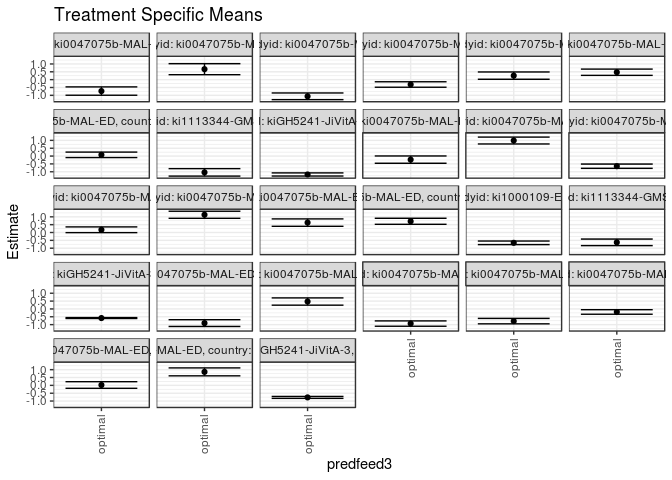

## Results Table

### Parameter: TSM

| agecat | studyid | country | intervention_level | baseline_level | estimate | ci_lower | ci_upper |
| --- | --- | --- | --- | --- | --- | --- | --- |
| Birth | ki0047075b-MAL-ED | BANGLADESH | optimal | observed | -0.9024110 | -1.1180976 | -0.6867244 |
| Birth | ki0047075b-MAL-ED | BRAZIL | optimal | observed | 0.4721693 | 0.2400386 | 0.7043000 |
| Birth | ki0047075b-MAL-ED | INDIA | optimal | observed | -0.9319014 | -1.1022586 | -0.7615442 |
| Birth | ki0047075b-MAL-ED | NEPAL | optimal | observed | -0.7771511 | -0.9505528 | -0.6037494 |
| Birth | ki0047075b-MAL-ED | PERU | optimal | observed | -0.1933209 | -0.3389122 | -0.0477296 |
| Birth | ki0047075b-MAL-ED | SOUTH AFRICA | optimal | observed | 0.0233132 | -0.1883016 | 0.2349280 |
| Birth | ki0047075b-MAL-ED | TANZANIA, UNITED REPUBLIC OF | optimal | observed | 0.8602317 | 0.6084738 | 1.1119896 |
| Birth | kiGH5241-JiVitA-3 | BANGLADESH | optimal | observed | -0.7667828 | -0.8278111 | -0.7057544 |
| 6 months | ki0047075b-MAL-ED | BANGLADESH | optimal | observed | -0.2267291 | -0.4591957 | 0.0057375 |
| 6 months | ki0047075b-MAL-ED | BRAZIL | optimal | observed | 0.9904588 | 0.7728375 | 1.2080800 |
| 6 months | ki0047075b-MAL-ED | INDIA | optimal | observed | -0.6453387 | -0.7815965 | -0.5090810 |
| 6 months | ki0047075b-MAL-ED | NEPAL | optimal | observed | 0.1741608 | -0.0093831 | 0.3577046 |
| 6 months | ki0047075b-MAL-ED | PERU | optimal | observed | 1.1308410 | 0.9060039 | 1.3556780 |
| 6 months | ki0047075b-MAL-ED | SOUTH AFRICA | optimal | observed | 0.6319981 | 0.3965181 | 0.8674781 |
| 6 months | ki0047075b-MAL-ED | TANZANIA, UNITED REPUBLIC OF | optimal | observed | 0.7144907 | 0.5221413 | 0.9068401 |
| 6 months | ki1000109-EE | PAKISTAN | optimal | observed | -0.6572810 | -0.7715263 | -0.5430357 |
| 6 months | ki1113344-GMS-Nepal | NEPAL | optimal | observed | -0.6267969 | -0.8346625 | -0.4189314 |
| 6 months | kiGH5241-JiVitA-3 | BANGLADESH | optimal | observed | -0.5819510 | -0.6110203 | -0.5528818 |
| 24 months | ki0047075b-MAL-ED | BANGLADESH | optimal | observed | -0.7293151 | -0.9946151 | -0.4640151 |
| 24 months | ki0047075b-MAL-ED | BRAZIL | optimal | observed | 0.6668366 | 0.3153103 | 1.0183629 |
| 24 months | ki0047075b-MAL-ED | INDIA | optimal | observed | -1.0615286 | -1.2731651 | -0.8498920 |
| 24 months | ki0047075b-MAL-ED | NEPAL | optimal | observed | -0.3096142 | -0.4844613 | -0.1347672 |
| 24 months | ki0047075b-MAL-ED | PERU | optimal | observed | 0.2556847 | 0.0229034 | 0.4884660 |
| 24 months | ki0047075b-MAL-ED | SOUTH AFRICA | optimal | observed | 0.4720685 | 0.2717968 | 0.6723402 |
| 24 months | ki0047075b-MAL-ED | TANZANIA, UNITED REPUBLIC OF | optimal | observed | 0.0785264 | -0.0959576 | 0.2530104 |
| 24 months | ki1113344-GMS-Nepal | NEPAL | optimal | observed | -1.0385320 | -1.2769192 | -0.8001448 |
| 24 months | kiGH5241-JiVitA-3 | BANGLADESH | optimal | observed | -1.1732499 | -1.2733144 | -1.0731853 |

### Parameter: E(Y)

| agecat | studyid | country | intervention_level | baseline_level | estimate | ci_lower | ci_upper |
| --- | --- | --- | --- | --- | --- | --- | --- |
| Birth | ki0047075b-MAL-ED | BANGLADESH | observed | observed | -0.9701762 | -1.1093516 | -0.8310008 |
| Birth | ki0047075b-MAL-ED | BRAZIL | observed | observed | 0.3837288 | 0.2059602 | 0.5614974 |
| Birth | ki0047075b-MAL-ED | INDIA | observed | observed | -1.0824352 | -1.2259825 | -0.9388879 |
| Birth | ki0047075b-MAL-ED | NEPAL | observed | observed | -0.9184337 | -1.0582074 | -0.7786600 |
| Birth | ki0047075b-MAL-ED | PERU | observed | observed | -0.0558491 | -0.1687562 | 0.0570581 |
| Birth | ki0047075b-MAL-ED | SOUTH AFRICA | observed | observed | -0.0290476 | -0.1772448 | 0.1191495 |
| Birth | ki0047075b-MAL-ED | TANZANIA, UNITED REPUBLIC OF | observed | observed | 0.7865789 | 0.5832028 | 0.9899551 |
| Birth | kiGH5241-JiVitA-3 | BANGLADESH | observed | observed | -0.7675034 | -0.7946123 | -0.7403944 |
| 6 months | ki0047075b-MAL-ED | BANGLADESH | observed | observed | -0.1245816 | -0.2544517 | 0.0052886 |
| 6 months | ki0047075b-MAL-ED | BRAZIL | observed | observed | 0.9717225 | 0.8073791 | 1.1360658 |
| 6 months | ki0047075b-MAL-ED | INDIA | observed | observed | -0.7105222 | -0.8368775 | -0.5841669 |
| 6 months | ki0047075b-MAL-ED | NEPAL | observed | observed | 0.1010587 | -0.0308005 | 0.2329178 |
| 6 months | ki0047075b-MAL-ED | PERU | observed | observed | 1.0571296 | 0.9346064 | 1.1796528 |
| 6 months | ki0047075b-MAL-ED | SOUTH AFRICA | observed | observed | 0.5435551 | 0.3895443 | 0.6975659 |
| 6 months | ki0047075b-MAL-ED | TANZANIA, UNITED REPUBLIC OF | observed | observed | 0.5063403 | 0.3745918 | 0.6380888 |
| 6 months | ki1000109-EE | PAKISTAN | observed | observed | -0.7218667 | -0.8355727 | -0.6081607 |
| 6 months | ki1113344-GMS-Nepal | NEPAL | observed | observed | -0.6194068 | -0.7173394 | -0.5214742 |
| 6 months | kiGH5241-JiVitA-3 | BANGLADESH | observed | observed | -0.5895220 | -0.6174288 | -0.5616152 |
| 24 months | ki0047075b-MAL-ED | BANGLADESH | observed | observed | -0.8080769 | -0.9302432 | -0.6859106 |
| 24 months | ki0047075b-MAL-ED | BRAZIL | observed | observed | 0.4466272 | 0.2416144 | 0.6516401 |
| 24 months | ki0047075b-MAL-ED | INDIA | observed | observed | -0.9551111 | -1.0714034 | -0.8388188 |
| 24 months | ki0047075b-MAL-ED | NEPAL | observed | observed | -0.3795556 | -0.4938120 | -0.2652991 |
| 24 months | ki0047075b-MAL-ED | PERU | observed | observed | 0.1242714 | 0.0054301 | 0.2431126 |
| 24 months | ki0047075b-MAL-ED | SOUTH AFRICA | observed | observed | 0.4157543 | 0.2953789 | 0.5361297 |
| 24 months | ki0047075b-MAL-ED | TANZANIA, UNITED REPUBLIC OF | observed | observed | 0.0434286 | -0.0830724 | 0.1699295 |
| 24 months | ki1113344-GMS-Nepal | NEPAL | observed | observed | -1.1267450 | -1.2257791 | -1.0277110 |
| 24 months | kiGH5241-JiVitA-3 | BANGLADESH | observed | observed | -1.2937057 | -1.3268339 | -1.2605775 |

### Parameter: PAR

| agecat | studyid | country | intervention_level | baseline_level | estimate | ci_lower | ci_upper |
| --- | --- | --- | --- | --- | --- | --- | --- |
| Birth | ki0047075b-MAL-ED | BANGLADESH | optimal | observed | -0.0677652 | -0.2570950 | 0.1215646 |
| Birth | ki0047075b-MAL-ED | BRAZIL | optimal | observed | -0.0884405 | -0.2366775 | 0.0597965 |
| Birth | ki0047075b-MAL-ED | INDIA | optimal | observed | -0.1505338 | -0.2641075 | -0.0369602 |
| Birth | ki0047075b-MAL-ED | NEPAL | optimal | observed | -0.1412826 | -0.2491581 | -0.0334072 |
| Birth | ki0047075b-MAL-ED | PERU | optimal | observed | 0.1374718 | 0.0268517 | 0.2480920 |
| Birth | ki0047075b-MAL-ED | SOUTH AFRICA | optimal | observed | -0.0523608 | -0.2270985 | 0.1223768 |
| Birth | ki0047075b-MAL-ED | TANZANIA, UNITED REPUBLIC OF | optimal | observed | -0.0736528 | -0.3004548 | 0.1531493 |
| Birth | kiGH5241-JiVitA-3 | BANGLADESH | optimal | observed | -0.0007206 | -0.0573649 | 0.0559237 |
| 6 months | ki0047075b-MAL-ED | BANGLADESH | optimal | observed | 0.1021475 | -0.1158844 | 0.3201795 |
| 6 months | ki0047075b-MAL-ED | BRAZIL | optimal | observed | -0.0187363 | -0.1702563 | 0.1327837 |
| 6 months | ki0047075b-MAL-ED | INDIA | optimal | observed | -0.0651834 | -0.1453674 | 0.0150005 |
| 6 months | ki0047075b-MAL-ED | NEPAL | optimal | observed | -0.0731021 | -0.1986358 | 0.0524316 |
| 6 months | ki0047075b-MAL-ED | PERU | optimal | observed | -0.0737113 | -0.2526707 | 0.1052480 |
| 6 months | ki0047075b-MAL-ED | SOUTH AFRICA | optimal | observed | -0.0884430 | -0.2680303 | 0.0911444 |
| 6 months | ki0047075b-MAL-ED | TANZANIA, UNITED REPUBLIC OF | optimal | observed | -0.2081504 | -0.3600608 | -0.0562400 |
| 6 months | ki1000109-EE | PAKISTAN | optimal | observed | -0.0645857 | -0.1061235 | -0.0230478 |
| 6 months | ki1113344-GMS-Nepal | NEPAL | optimal | observed | 0.0073901 | -0.1739277 | 0.1887079 |
| 6 months | kiGH5241-JiVitA-3 | BANGLADESH | optimal | observed | -0.0075710 | -0.0155557 | 0.0004138 |
| 24 months | ki0047075b-MAL-ED | BANGLADESH | optimal | observed | -0.0787618 | -0.3282456 | 0.1707219 |
| 24 months | ki0047075b-MAL-ED | BRAZIL | optimal | observed | -0.2202094 | -0.4694118 | 0.0289931 |
| 24 months | ki0047075b-MAL-ED | INDIA | optimal | observed | 0.1064175 | -0.0799702 | 0.2928051 |
| 24 months | ki0047075b-MAL-ED | NEPAL | optimal | observed | -0.0699413 | -0.1875795 | 0.0476969 |
| 24 months | ki0047075b-MAL-ED | PERU | optimal | observed | -0.1314133 | -0.3131439 | 0.0503173 |
| 24 months | ki0047075b-MAL-ED | SOUTH AFRICA | optimal | observed | -0.0563142 | -0.2071320 | 0.0945037 |
| 24 months | ki0047075b-MAL-ED | TANZANIA, UNITED REPUBLIC OF | optimal | observed | -0.0350978 | -0.1294770 | 0.0592813 |
| 24 months | ki1113344-GMS-Nepal | NEPAL | optimal | observed | -0.0882131 | -0.3111259 | 0.1346998 |
| 24 months | kiGH5241-JiVitA-3 | BANGLADESH | optimal | observed | -0.1204558 | -0.2133556 | -0.0275559 |